# —

# Main Conclusions

## main conclusion

### when purchasing a second-hand home, Below is a property recommendation analysis solution based on the relationship between property age, size, and price.

## code and documents

### for more details on using data analysis see https://github.com/tigerwangcqupt/r_projects-static_project_lj.git.

# Analysis of ideas and methods

## ideas

### property age is negatively correlated with price (older properties are priced lower)

### building age depreciation coefficient = 1/(1+0.02*building_age) (assuming an annual depreciation rate of 2%)

### cost-performance score = (Standardized area * 0.6 + Standardized building age coefficient * 0.4) / Standardized unit price

### the top 10 houses with the highest cost-performance ratio have been selected

## methods

### collect Shanghai Lianjia housing data to form an R dataset.

### using RStudio tools and R code libraries for data analysis

### it requires the use of many R language libraries, including the library collection: tidyverse, dplyr, and so on.

### using R code, output a scatter plot showing the relationship between the construction age and floor area of houses.

# Analysis Process

## detail process

### sort and output the top 10 listings by cost-performance score

### use a blue-to-red gradient color scheme to enhance visualization

## r programming

```r
# Simulated Data Generation
library(ggplot2)
library(dplyr)
load("../data/lj_sh_2019.RData")
houses <- lj %>%
  mutate(building_age = 2025 - building_year) %>%
  filter(building_age <= 20)
# Cost-effectiveness calculation
houses <- houses %>%
  mutate(
    age_factor = 1/(1 + 0.02*building_age),
    value_score = (scale(building_area)*0.6 + scale(age_factor)*0.4)/scale(price_sqm)
  )
```

### plot lj geom_point chart and data table

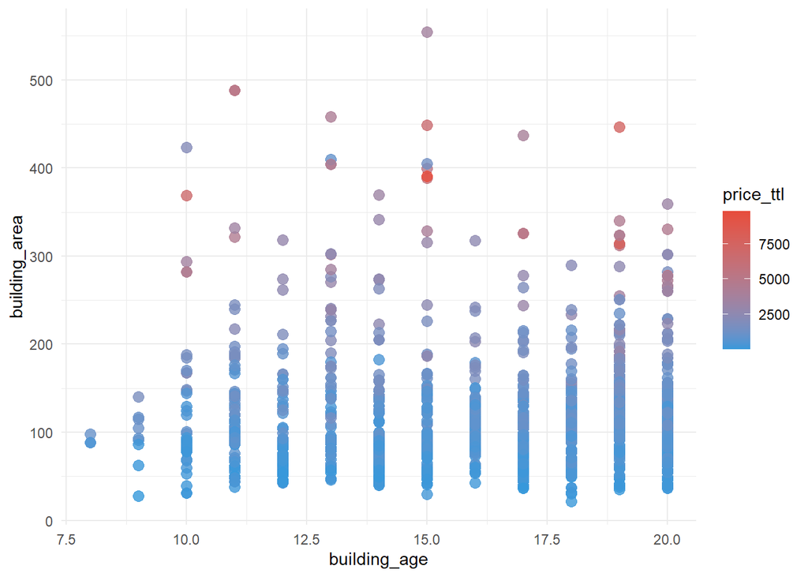

```r
ggplot(houses, aes(x=building_age, y=building_area, color=price_ttl)) +
  geom_point(size=3, alpha=0.8) +
  scale_color_gradient(low="#3498db", high="#e74c3c") +
  labs(x="building_age", y="building_area", color="price_ttl") +
  theme_minimal()
```

```r
top10 <- houses %>%
  arrange(desc(value_score)) %>%
  head(10) %>%
  select(property_name,building_age, building_area, price_ttl, price_sqm, value_score)
knitr::kable(
  head(top10, 300),
  caption = "statistics Top 10 listings sorted by value-for-money score",
  align = c("l", "c", "c", "r", "r","r")
)
```

statistics Top 10 listings sorted by value-for-money score

| property_name | building_age | building_area | price_ttl | price_sqm | value_score |
| --- | --- | --- | --- | --- | --- |
| 和平花苑 | 20 | 136.42 | 970 | 71104 | 97.17200 |
| 九歌上郡 | 19 | 106.29 | 755 | 71033 | 87.30199 |
| 林绿家园 | 18 | 64.93 | 460 | 70846 | 65.14400 |
| 江南星城 | 20 | 176.83 | 1260 | 71255 | 48.82631 |
| 创智坊(公寓) | 19 | 117.70 | 835 | 70944 | 43.70462 |
| 世茂滨江花园 | 20 | 228.68 | 1639 | 71673 | 38.27174 |
| 建发璟墅 | 11 | 244.44 | 1780 | 72820 | 37.37225 |
| 风度国际 | 20 | 114.48 | 810 | 70755 | 35.62858 |
| 风度国际 | 20 | 114.48 | 810 | 70755 | 35.62858 |
| 靖宇家园 | 18 | 77.26 | 545 | 70542 | 29.47729 |